# R Notebook

Shad, Edin

december 1, 2016

### Scientific methodology and preformance evaluation

# Winter School, ENS Lyon

We start with looking at the data provided on the web page: http://mescal.imag.fr/membres/arnaud.legrand/teaching/2013/M2R_EP_archive_quicksort.tgz

We won’t focus on the particular implemenation, although this is very important part of the experiment. We leave it for the future work. We rather analyse the data, as we would do if somebody would give us implementation as black boxes which we query. One way to think about this, is that we do not compare general which type of implementation works the best, but rather which out of three implementation is better for different sizes of arrays. So we turn towards the dereminig when we should use one of this three algorithm to get faster running times.

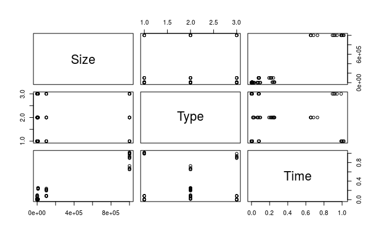

```r
data = read.csv("archive_quicksort/measurements.csv")
df = data.frame(data)
plot(df)
```

```r
summary(df)
```

```
      Size                  Type         Time
 Min.   :    100    Built-in  :25   Min.   :0.000039
 1st Qu.:   1000    Parallel  :25   1st Qu.:0.000714
 Median :  10000    Sequential:25   Median :0.076455
 Mean   : 222220                    Mean   :0.223024
 3rd Qu.: 100000                    3rd Qu.:0.239711
 Max.   :1000000                    Max.   :1.019417
```

The above plot didn’t say much. We observe that Size and Type are discrete variables and that Time should be assumed as continous. In order to see more, lets separate data according to the algorithm used.

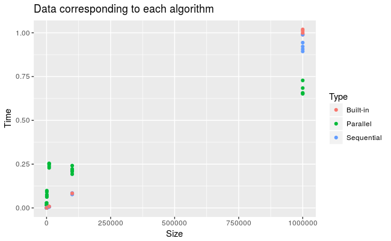

```r
library(ggplot2)
ggplot(df, aes(x = Size, y = Time, colour = Type,  group = Type)) + geom_point() + ggtitle("Data corresponding to each algorithm")
```

Obsearvtions: sizes for which the algorithms were tested are quite scaered and we can not conclude much. If we would have just this data, we could try to fit linear regression for each of the algorithms. Even if the results of linear regresion turn out to be good, the assumtion that the running time behaves linearly is very weak and probably not true. In any way we do the linear regresion for data of each algorithm. Before that, we plot again data of each algorithm separetely just to see if they look linear.

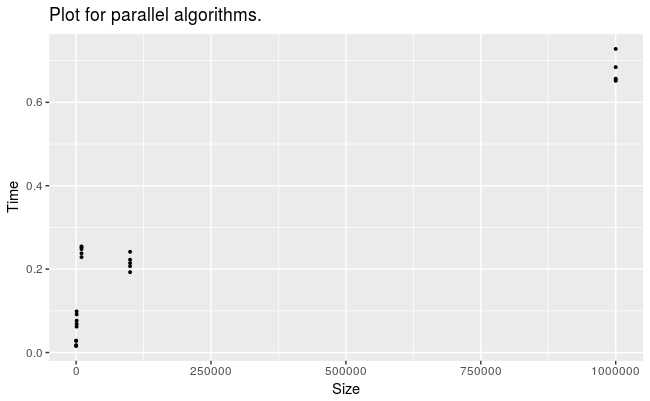

```r
para = df[df$Type == " Parallel",]
sequ = df[df$Type == " Sequential",]
builtIn = df[df$Type == " Built-in",]
ggplot(para, aes(x = Size, y= Time)) + geom_point(size = 0.7) + ggtitle("Plot for parallel algorithms.")
```

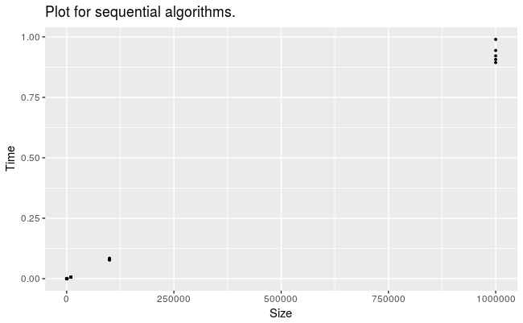

```r
ggplot(sequ, aes(x = Size, y= Time)) + geom_point(size = 0.7) + ggtitle("Plot for sequential algorithms.")
```

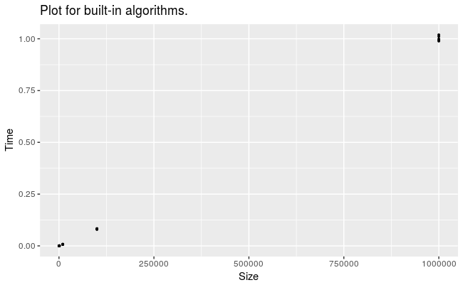

```r
ggplot(builtIn, aes(x = Size, y= Time)) + geom_point(size = 0.7) + ggtitle("Plot for built-in algorithms.")
```

```r
regp = lm(data = para, Time ~ Size)
summary(regp)
```

```
Call:
lm(formula = Time ~ Size, data = para)

Residuals:
     Min       1Q   Median       3Q      Max
-0.10783 -0.05543 -0.02297  0.04831  0.12536

Coefficients:
             Estimate Std. Error t value Pr(>|t|)
(Intercept) 1.235e-01  1.812e-02   6.816 5.96e-07 ***
Size        5.563e-07  4.032e-08  13.795 1.30e-12 ***
---
Signif. codes:  0 ‘***’ 0.001 ‘**’ 0.01 ‘*’ 0.05 ‘.’ 0.1 ‘ ’ 1

Residual standard error: 0.07877 on 23 degrees of freedom
Multiple R-squared:  0.8922,    Adjusted R-squared:  0.8875
F-statistic: 190.3 on 1 and 23 DF,  p-value: 1.304e-12
```

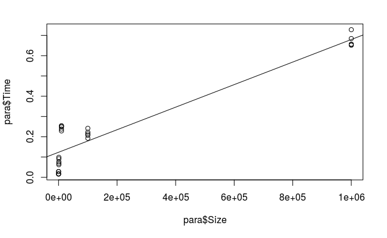

```r
plot(x = para$Size,y = para$Time)
abline(regp)
```

Results of linear fit for parallel algorithm seems quite strong for this data.

```r
regq = lm(data = sequ, Time ~ Size)
summary(regq)
```

```
Call:
lm(formula = Time ~ Size, data = sequ)

Residuals:
      Min        1Q    Median        3Q       Max
-0.036347 -0.008607  0.001317  0.004038  0.059532

Coefficients:
              Estimate Std. Error t value Pr(>|t|)
(Intercept) -4.092e-03  3.822e-03  -1.071    0.295
Size         9.343e-07  8.504e-09 109.864   <2e-16 ***
---
Signif. codes:  0 ‘***’ 0.001 ‘**’ 0.01 ‘*’ 0.05 ‘.’ 0.1 ‘ ’ 1

Residual standard error: 0.01661 on 23 degrees of freedom
Multiple R-squared:  0.9981,    Adjusted R-squared:  0.998
F-statistic: 1.207e+04 on 1 and 23 DF,  p-value: < 2.2e-16
```

```r
par(mfrow~c(1,1))
```

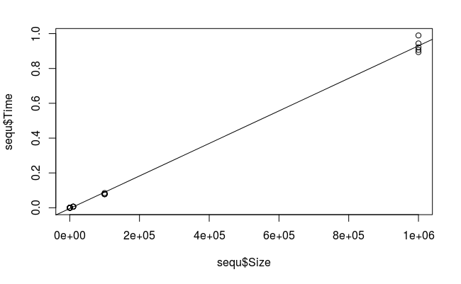

```r
plot(x = sequ$Size,y = sequ$Time)
abline(regq)
```

```r
regb = lm(data = builtIn, Time ~ Size)
summary(regb)
```

```
Call:
lm(formula = Time ~ Size, data = builtIn)

Residuals:
      Min        1Q    Median        3Q       Max
-0.015615 -0.007997  0.003712  0.005146  0.018362

Coefficients:
              Estimate Std. Error t value Pr(>|t|)
(Intercept) -5.206e-03  2.107e-03   -2.47   0.0213 *
Size         1.006e-06  4.689e-09  214.62   <2e-16 ***
---
Signif. codes:  0 ‘***’ 0.001 ‘**’ 0.01 ‘*’ 0.05 ‘.’ 0.1 ‘ ’ 1

Residual standard error: 0.009159 on 23 degrees of freedom
Multiple R-squared:  0.9995,    Adjusted R-squared:  0.9995
F-statistic: 4.606e+04 on 1 and 23 DF,  p-value: < 2.2e-16
```

```r
par(mfrow~c(1,1))
```

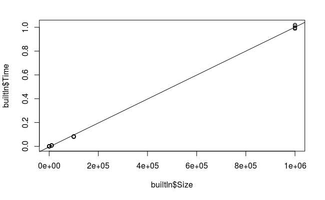

```r
plot(x = builtIn$Size,y = builtIn$Time)
abline(regb)
```

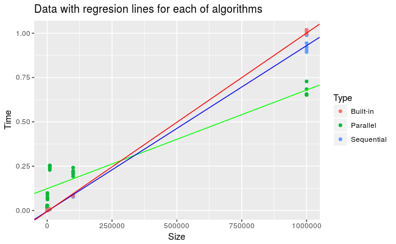

```r
ggplot(df, aes(x = Size, y = Time, colour = Type,  group = Type)) + geom_point() + ggtitle("Data with regresion lines for each of algorithms") + geom_abline(intercept = coef(regp)["(Intercept)"], slope = coef(regp)["Size"], colour = "green" ) +geom_abline(intercept = coef(regq)["(Intercept)"], slope = coef(regq)["Size"], colour = "blue" ) + geom_abline(intercept = coef(regb)["(Intercept)"], slope = coef(regb)["Size"], colour = "red" )
```

`Under above assumptions, the parallel algorithm seems to outrun the other two algorithms for the arrays of size bigger than 250000 and that sequential and built-in algorithm are alsmost the same. From this data it is not reliable to say that sequential is overall better than built-in since the data set is small, and not well calibrated. One more problem of the current data is that we don’t know how were they measured, on how many machines and what kind of machines. In order to imporve this, we generate new data sets using providede “black-boxes” and extend the data for sizes up to milion.

```r
dataEdin = read.csv("MyData/measurements.csv")
dE = data.frame(dataEdin)
summary(dE)
```

```
      Size                  Type         Time
 Min.   :    100    Built-in  :55   Min.   :0.000009
 1st Qu.:   1000    Parallel  :55   1st Qu.:0.001565
 Median :  50000    Sequential:55   Median :0.051495
 Mean   : 242418                    Mean   :0.100817
 3rd Qu.: 500000                    3rd Qu.:0.211804
 Max.   :1000000                    Max.   :0.309712
```

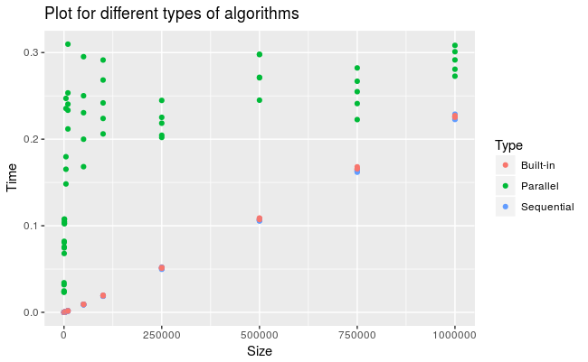

```r
ggplot(dE, aes(x = Size, y = Time, colour = Type,  group = Type)) + geom_point() + ggtitle("Plot for different types of algorithms")
```

We observe that the paralel algorithm shows very slow running time for smaller arrays. But it seems that it will be better after some big enough size. That is way we for the moment stop here, and try to get more data for the biggest sizes of arrays. But first, lets us see what happend with same procedure on different arhitecture.

```r
dataShad = read.csv("ShadMeasurements.csv")
dS = data.frame(dataShad)
summary(dS)
```

```
      Size                  Type         Time
 Min.   :    100    Built-in  :55   Min.   :0.000007
 1st Qu.:   1000    Parallel  :55   1st Qu.:0.001457
 Median :  50000    Sequential:55   Median :0.029517
 Mean   : 242418                    Mean   :0.073540
 3rd Qu.: 500000                    3rd Qu.:0.131701
 Max.   :1000000                    Max.   :0.326254
```

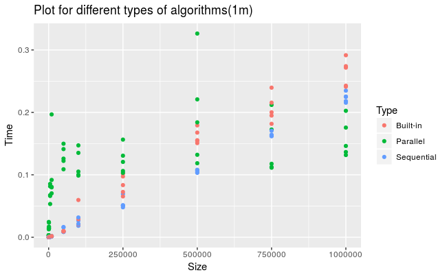

```r
ggplot(dS, aes(x = Size, y = Time, colour = Type,  group = Type)) + geom_point() + ggtitle("Plot for different types of algorithms(1m)")
```

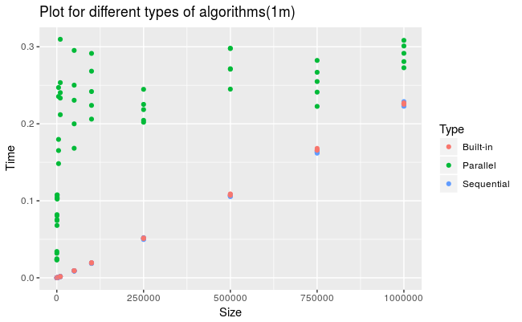

```r
ggplot(dE, aes(x = Size, y = Time, colour = Type,  group = Type)) + geom_point() + ggtitle("Plot for different types of algorithms(1m)")
```

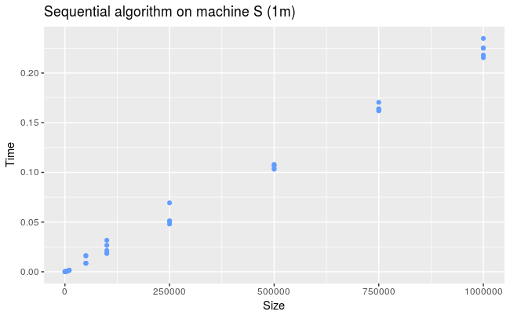

```r
ggplot(dS[dS$Type == " Sequential",],  aes(x = Size, y = Time, colour = Type,  group = Type)) + geom_point(colour="#619CFF") + ggtitle("Sequential algorithm on machine S (1m)")
```

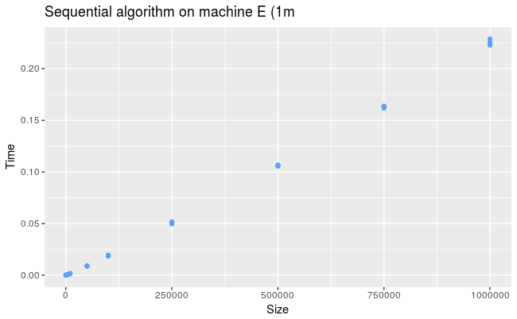

```r
ggplot(dE[dE$Type == " Sequential",] , aes(x = Size, y = Time, colour = Type,  group = Type)) + geom_point(colour="#619CFF") + ggtitle("Sequential algorithm on machine E (1m")
```

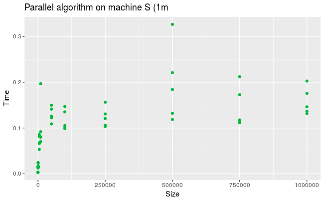

```r
ggplot(dS[dS$Type == " Parallel",],  aes(x = Size, y = Time, colour = Type,  group = Type)) + geom_point(colour="#00BA38") + ggtitle("Parallel algorithm on machine S (1m")
```

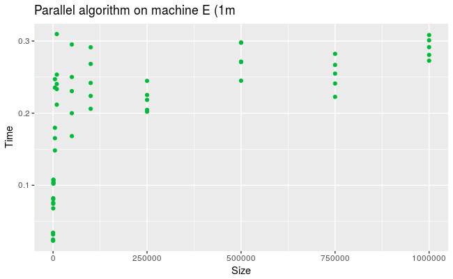

```r
ggplot(dE[dE$Type == " Parallel",] , aes(x = Size, y = Time, colour = Type,  group = Type)) + geom_point(colour="#00BA38") + ggtitle("Parallel algorithm on machine E (1m")
```

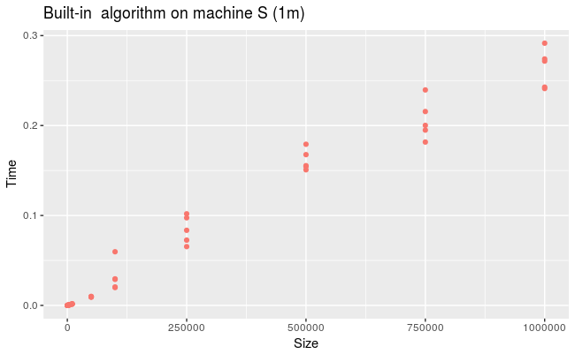

```r
ggplot(dS[dS$Type == " Built-in",],  aes(x = Size, y = Time, colour = Type,  group = Type)) + geom_point(colour = "#F8766D") + ggtitle("Built-in  algorithm on machine S (1m)")
```

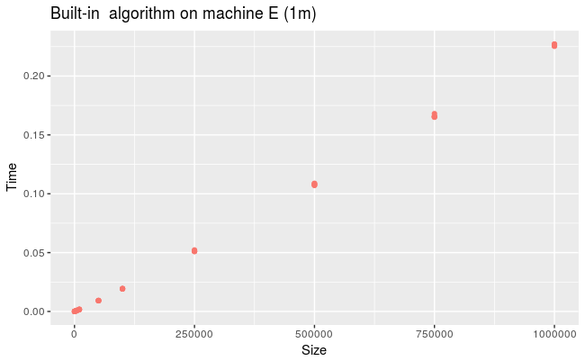

```r
ggplot(dE[dE$Type == " Built-in",] , aes(x = Size, y = Time, colour = Type,  group = Type)) + geom_point(colour = "#F8766D") + ggtitle("Built-in  algorithm on machine E (1m)")
```

We observe that in both cases the parallel algorithm doesn’t follow linear scaling, while both sequential and built-in algorithm show linear increase of execution time with the size. We also decide that for better estimated we need to increase the maximum size. We move the maximum up to two milion.

```r
dataEdin2 = read.csv("MyData2milion/measurements.csv")
dE2 = data.frame(dataEdin2)
summary(dE2)
```

```
      Size                  Type         Time
 Min.   :    100    Built-in  :75   Min.   :0.000009
 1st Qu.:   5000    Parallel  :75   1st Qu.:0.009231
 Median : 250000    Sequential:75   Median :0.162244
 Mean   : 611107                    Mean   :0.174722
 3rd Qu.:1250000                    3rd Qu.:0.294626
 Max.   :2000000                    Max.   :0.499404
```

We again plot it, to get more intution.

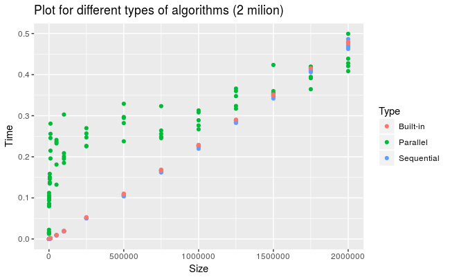

```r
ggplot(dE2, aes(x = Size, y = Time, colour = Type,  group = Type)) + geom_point() + ggtitle("Plot for different types of algorithms (2 milion)")
```